# Genomic analysis: Pt I

Neel Mukherjee  
March 5, 2020

### Goal:

Integrate genomic datasets.

Perform analysis on genomic sequences.

But first some background…

### mature mRNA regulatory decisions

[figure not shown]

### RNA-binding proteins

ELAVL1/HuR is an essential RNA-binding protein (RBP). HuR binds to AU-rich elements (ARE) in 3’ UTRs of mRNAs to promote mRNA stability and translation.

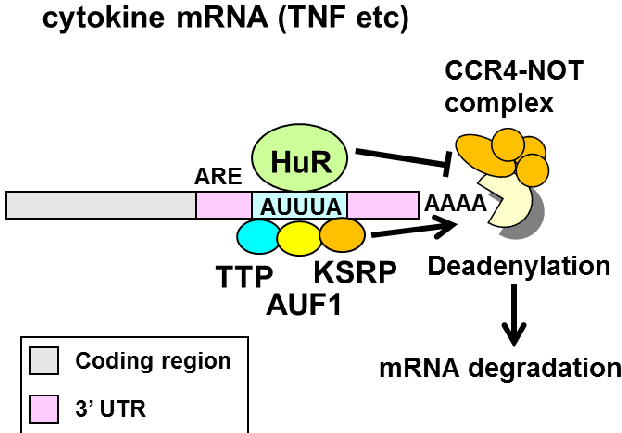

### Mapping RBP-RNA interaction sites: PAR-CLIP

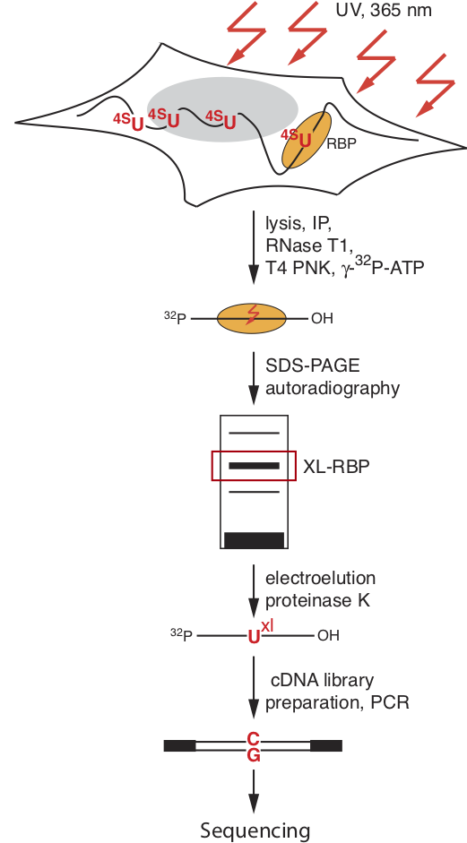

### Hypothesis:

*HuR binds to AU-rich elements in the 3' UTR of mRNAs to promote stability.*

Our datasets: 1. HuR-RNA binding sites (PAR-CLIP) in human cell lines (hg19)  
2. HuR vs scramble siRNA KD RNA-seq data

### Questions:

Where in mRNA does HuR bind mRNA? Which regions are enriched for HuR binding?

What sequences does HuR bind to? Are those sequences enriched for HuR binding compared to background?

Does HuR promote the stability of its mRNA targets? Does the region or number of HuR binding influence stabilization?

### HuR PAR-CLIP data: import

Read in data

```r
# get data
hur_parclip <- read_tsv("data/SRR248532_clusters.tsv.zip")
```

### HuR PAR-CLIP data: import

For the purpose of this exercise we will be focus on mRNAs to keep it simple.

```r
# modify 5'UTR to get rid of " ' "
hur_parclip$Aligned.to <- gsub(pattern = "5'utr", replacement =  "utr5", x =  hur_parclip$Aligned.to)

# same for 3'UTR
hur_parclip$Aligned.to <- gsub("3'utr", "utr3", hur_parclip$Aligned.to)
```

### A bit of simple EDA

Let's look at the HuR binding sites sizes:

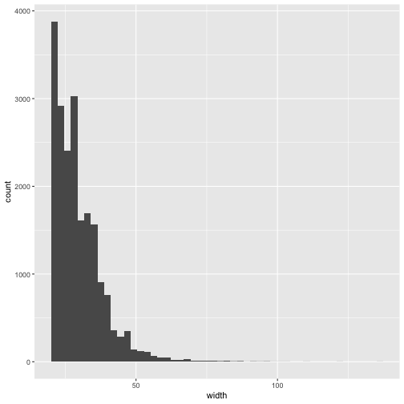

```r
ggplot(data=hur_parclip %>% filter(Aligned.to=="utr3"), aes(x=width)) +
  geom_histogram(bins = 50)
```

### HuR PAR-CLIP data: annotation

```r
# annotation categories that HuR binds to
binding_regions_all <- hur_parclip %>%
  count(Aligned.to) %>%
  arrange(desc(n)) %>%
  mutate(freq=n/sum(n))

binding_regions_all
```

```
# A tibble: 39 x 3
   Aligned.to                  n    freq
   <chr>                   <int>   <dbl>
 1 intron                  60846 0.547
 2 utr3                    20490 0.184
 3 NoAnnotation            18694 0.168
 4 processed_transcript     2621 0.0236
 5 repeat                   2277 0.0205
 6 lincRNA_intron           1813 0.0163
 7 antisense                1220 0.0110
 8 coding                    825 0.00742
 9 lincRNA_exon              495 0.00445
10 nonsense_mediated_decay   431 0.00387
# … with 29 more rows
```

### HuR PAR-CLIP data: pie chart

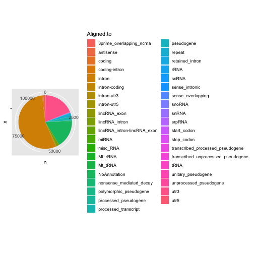

```r
ggplot(binding_regions_all, aes(x="", y=n, fill=Aligned.to)) +
  geom_bar(width = 1, stat = "identity") +
  coord_polar("y", start=0)
```

### Too many categories

```r
mRNA_regions <- c("utr5","coding","intron", "utr3")
hur_parclip %>%
  filter(Aligned.to %in% mRNA_regions) %>%
  count(Aligned.to) %>%
  summarise(fraction_mRNA=sum(n)/nrow(hur_parclip))
```

```
# A tibble: 1 x 1
  fraction_mRNA
          <dbl>
1         0.741
```

```r
hur_parclip_mRNA <- hur_parclip %>%
  filter(Aligned.to %in% mRNA_regions)

binding_regions_mRNA <- hur_parclip_mRNA %>%
  count(Aligned.to) %>%
  arrange(desc(n)) %>%
  mutate(freq=n/sum(n))
```

### HuR PAR-CLIP data: pie chart 2

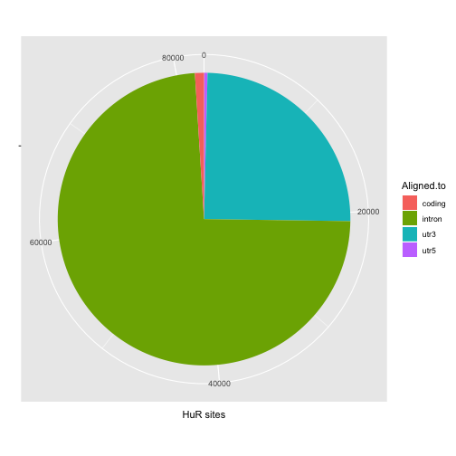

```r
ggplot(binding_regions_mRNA, aes(x="", y=n, fill=Aligned.to)) +
  geom_bar(width = 1, stat = "identity") +
  coord_polar("y") + xlab("") + ylab("HuR sites")
```

```r
  theme(axis.text.x=element_blank())
```

```
List of 1
 $ axis.text.x: list()
  ..- attr(*, "class")= chr [1:2] "element_blank" "element"
 - attr(*, "class")= chr [1:2] "theme" "gg"
 - attr(*, "complete")= logi FALSE
 - attr(*, "validate")= logi TRUE
```

### Which regions are enriched for HuR binding?

The majority of HuR mRNA binding sites are in introns and 3' UTRs.

About ¾ of HuR binding sites are in introns and ¼ in 3' UTRs.

There are 2.97x more binding sites in intron vs 3' UTR. This would suggest that HuR preferentially binds to introns. However introns are much longer than 3' UTRs.

So if the average intron is 3x longer than the average 3'UTR - then HuR would exhibit similar binding preference.

### Let's figure out the length of introns and 3' UTRs.

We need a gtf file with [gene/transcript models](https://www.gencodegenes.org/human/release_19.html).

```r
# if (!file.exists("data/gencodev19.sqlite")) {
#   txdb <- makeTxDbFromGFF("ftp://ftp.ebi.ac.uk/pub/databases/gencode/Gencode_human/release_19/gencode.v19.annotation.gtf.gz", format="gtf")
#   saveDb(txdb,file="data/gencodev19.sqlite")
# }

# BiocManager::install("TxDb.Hsapiens.UCSC.hg19.knownGene")
library("TxDb.Hsapiens.UCSC.hg19.knownGene")
txdb <- TxDb.Hsapiens.UCSC.hg19.knownGene #shorthand
```

### I LIED - only doing 3' UTRs...

```r
utr3  <- threeUTRsByTranscript(txdb)
utr3 <- GenomicRanges::reduce(unlist(utr3))
mean(width(utr3))
```

```
[1] 1099.604
```

### However...

Remember, there are 2.97x more binding sites in intron vs 3' UTR.

The mean intron length is 6.36x longer than mean 3' UTR length.

Therefore, based on mean region length HuR is 2.14x more likely to bind in 3' UTRs than introns.

### 5 Minute Break

### What sequences does HuR bind to?

We are going to restrict our analysis to the 3'UTR binding sites for class.

```r
hur_utr3 <- hur_parclip %>% filter(Aligned.to=="utr3")

# make DNAStringSet
hur_string <- DNAStringSet(hur_utr3$ClusterSequence)
names(hur_string) <- hur_utr3$Aligned.to
```

### HuR 6mer binding frequencies

```r
hur_6mer <- data.frame(
  count=oligonucleotideFrequency(x = unlist(hur_string), width = 6)
  )

hur_6mer$nuc <- rownames(hur_6mer) # make new column 6mer
hur_6mer$freq <- hur_6mer$count/sum(hur_6mer$count) # calc freq
hur_6mer$freq_rand <- hur_6mer$freq/(1/4096) # vs uniform
hur_6mer <- hur_6mer %>% arrange(desc(count))
```

### What sequences does HuR bind to?

So we now know that HuR really likes UUUUUU - perhaps even better than it likes AU-rich elements!

```r
hur_6mer %>% filter(freq_rand > 30)
```

```
   count    nuc        freq freq_rand
1  18570 TTTTTT 0.030543667 125.10686
2   6431 ATTTTT 0.010577616  43.32591
3   6372 TTTTTA 0.010480573  42.92843
4   5774 TATTTT 0.009496992  38.89968
5   5335 TTATTT 0.008774931  35.94212
6   5066 TTTATT 0.008332484  34.12985
7   5015 TTTTTC 0.008248599  33.78626
8   4947 CTTTTT 0.008136754  33.32814
9   4798 TTTTAT 0.007891681  32.32433
10  4785 TTTTCT 0.007870299  32.23674
11  4770 TTTTAA 0.007845627  32.13569
12  4493 TTTCTT 0.007390021  30.26953
```

### Visualize sequence motif

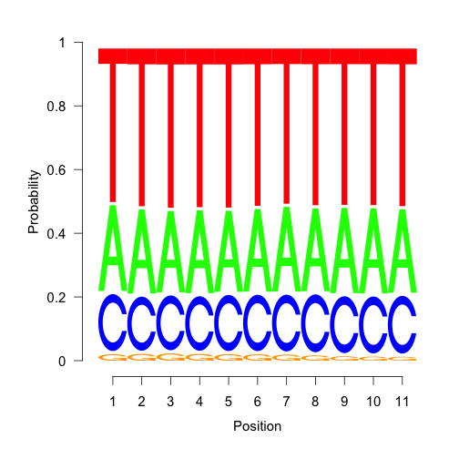

```r
hur_string_20 <- DNAStringSet(hur_string, start = 5, end = 15) # only keeping the nts 5-15
letter_counts <- consensusMatrix(hur_string_20)
probs <- prop.table(letter_counts[1:4,], 2)

seqLogo(probs, ic.scale = F)
```

### Are those sequences enriched for HuR binding compared to background?

But we need to normalize for the frequency of these sequences in 3' UTRs. For this task we need to retrieve the sequences 3' UTRs.

### How to get genomic sequences

```r
library(BSgenome.Hsapiens.UCSC.hg19)
threeUTR_seqs <- getSeq(BSgenome.Hsapiens.UCSC.hg19, utr3)

threeUTR_seqs <- DNAStringSet(unlist(threeUTR_seqs))
```

### Calculate 6mer counts and frequencies in 3'UTRs

```r
utr3_6mer <- data.frame(countUTRs=oligonucleotideFrequency(x = unlist(threeUTR_seqs), width = 6, as.prob = F))
utr3_6mer$utrfreqs <- utr3_6mer$count/sum(utr3_6mer$count)
utr3_6mer$nuc <- rownames(utr3_6mer)

my_6mer <- left_join(hur_6mer, utr3_6mer, by = "nuc")
my_6mer$freq_utr <- my_6mer$freq/my_6mer$utrfreqs
```

### Make a plot

```r
p_6mer <- ggplot(data = my_6mer, aes(y = freq, x = utrfreqs)) +
  geom_point(color = ifelse(my_6mer$freq_utr > 7, "red", "black")) +
  theme_few() + ylab("HuR 3'UTR site 6mers") + xlab("3'UTR 6mers") +
  geom_abline(intercept = 0, slope = 1) +
  geom_text_repel(aes(label=ifelse(my_6mer$freq_utr > 7,
                             my_6mer$nuc,
                             "")))
```

### Take a look

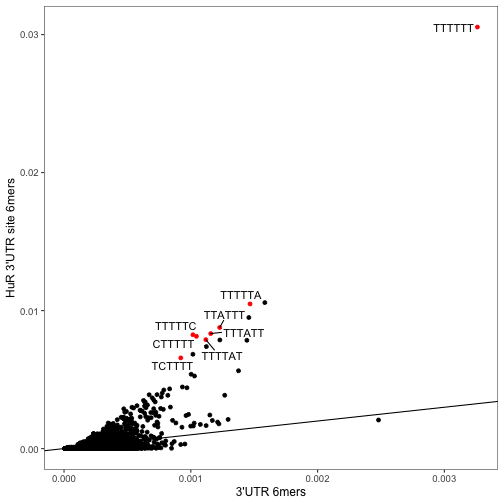

```r
p_6mer
```